# Projekt: 732G33: del 1

*Författare:* Jakob Eklund & Pelle Nyberg

*Liu-id:* jakek854 & pelny705

*Grupp:* 06

# Introduktion

För kommunaldata har vi hämtat data för variablerna medelålder, medelinkomst, andel utlandsfödda, andel moppar och även befolkning. För tiddserie har vi hämtat data för konsumentprisindex (KPI) på riksnivå i Sverige. Tidsserien är på månadsnivå och innefattar perioden january 2012 till december 2021. Den innefattar en period om tio år och totalt 120 månader. Dessa månader har konverterats till ett datumintervall i paketet lubridate. Datan för KPI har konverterats så att den börjar med basen 100 där valt intervall börjar. All använd data har hämtats från SCB.

# Kommundata

Tabell över variabler

[output not shown]

I denna tabell har vi data för medelålder, medellön på årsbasis(tkr), antal utlandsfödda per 100 invånare, antal moppar per 100 invånare samt antalet invånare. Våra kommuner vi har användt oss av står i kolumnen “Kommun”. Varje rad representerar en kommun.

Tabell över statistiska mått

[output not shown]

Ovan visar en tabell våra 4 variabler samt befolknings-variabeln. Tabllen visar dessa varibler samt vad medelvärdet,medianen, standardavikelsen, minsta och största obeservationen av samtliga variabler. I denna tabell till skillnad från den ovanför så är representerar variablerna Sveriges samtliga regioner, inte enbart våra utvalda kommuner.

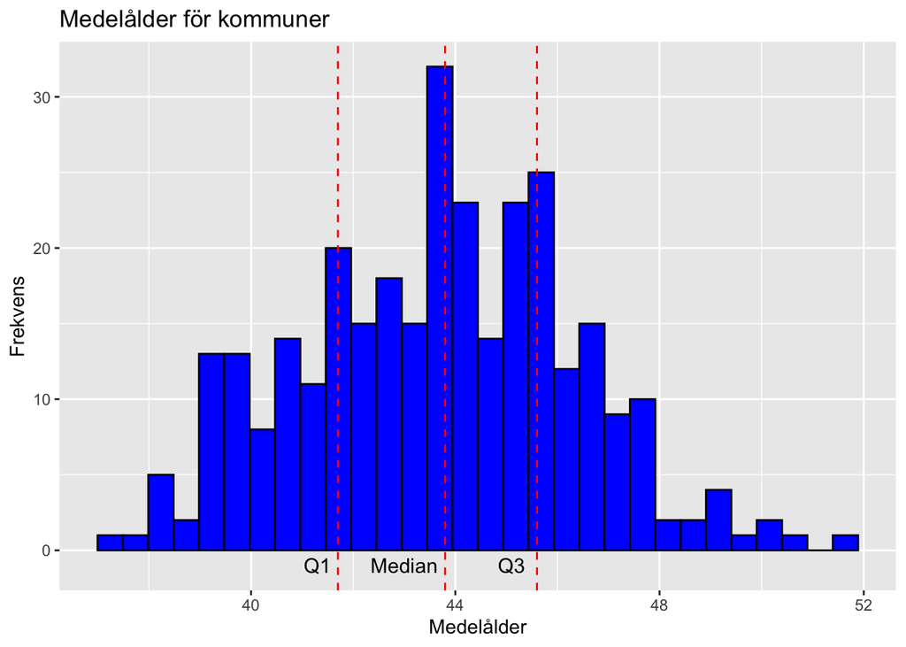

Detta histogram representerar medelålder för de olika kommunernas befolkning. Vi har röda vertikala linjer som representerar första och tredje kvartil, samt medianen. Det som kan sägas om datan är att den är någorlunda normalfördelad.

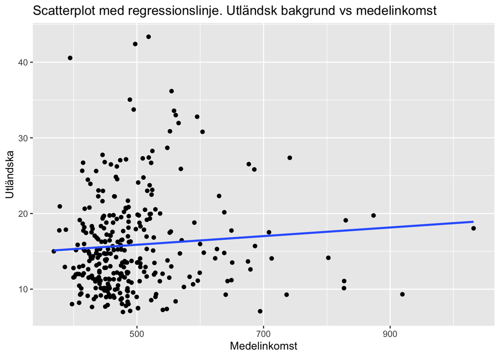

Ovan har vi en scatterplot mellan två variabler. Medelinkomst på x-axeln och andel personer med utländsk bakgrund. Med regressionslinjens positiva lutning så skulle det kunna tolkas som att person med utländsk bakgrund har högre inkomst i medel. Lutning är däremot inte så brant så det skulle behövas mer data för att vidare undersöka sambandet.

Tabell för korrelationstest

| T.value | 1.1965 |
| --- | --- |
| Df | 310 |
| P.value | 0.2324 |
| X95..CI | -0.04356668 - 0.17750238 |
| Correlation | 0.0678 |

# Datanalys av tidsseriedata

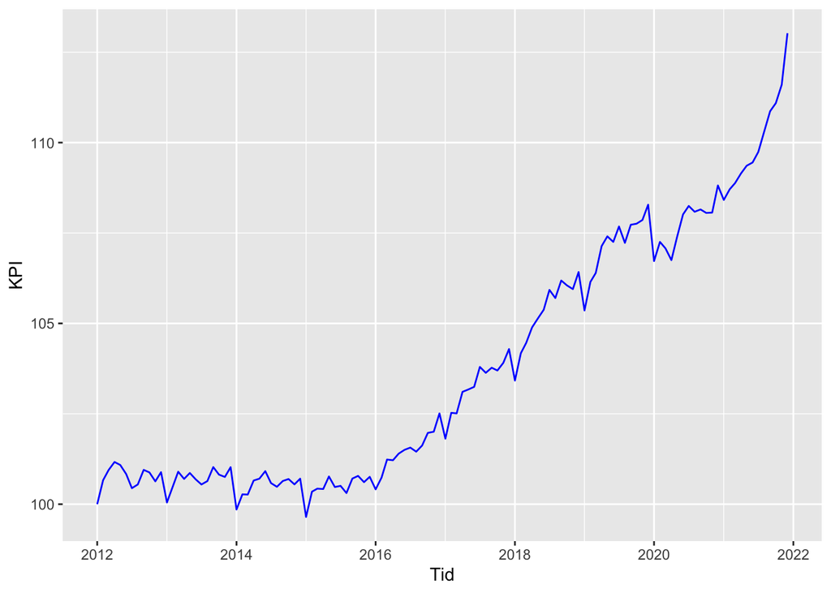

En tidsserie över perioden 1 januari 2012 till 31 december 2021. Där data hämtas från SCB och perioden har justerats så att basåret är 2012.

| Månad | Medel KPI |
| --- | --- |
| Jan | 102.5685 |
| Feb | 103.1323 |
| Mar | 103.3093 |
| Apr | 103.5187 |
| Maj | 103.7284 |
| Jun | 103.7752 |
| Jul | 103.9035 |
| Aug | 103.8381 |
| Sep | 104.1655 |
| Okt | 104.1799 |
| Nov | 104.1930 |
| Dec | 104.6715 |

Tabell för medelvärden månadsvis för KPI. Perioden 2012-2021.

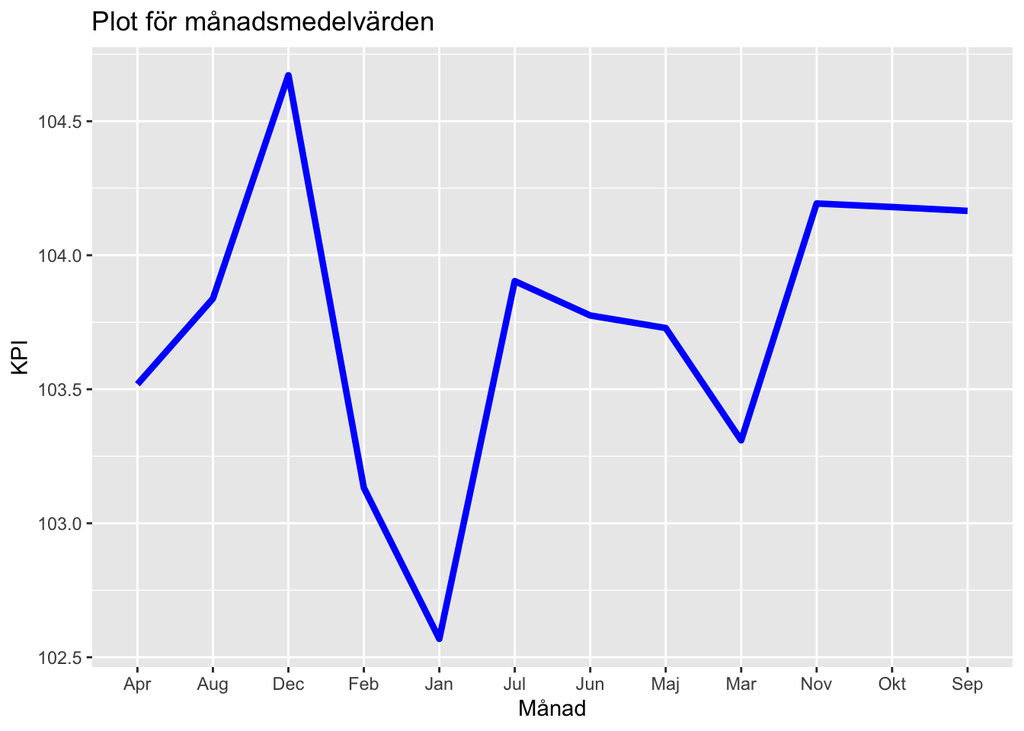

En plot för medelvärden för KPI. Med olika månaders medelvärden på X-axeln. Perioden 2012-2021. Det som går att utläsa från detta samt från tabellen är det faktum att medelvärdet är som lägst i januari och högst i december månad.

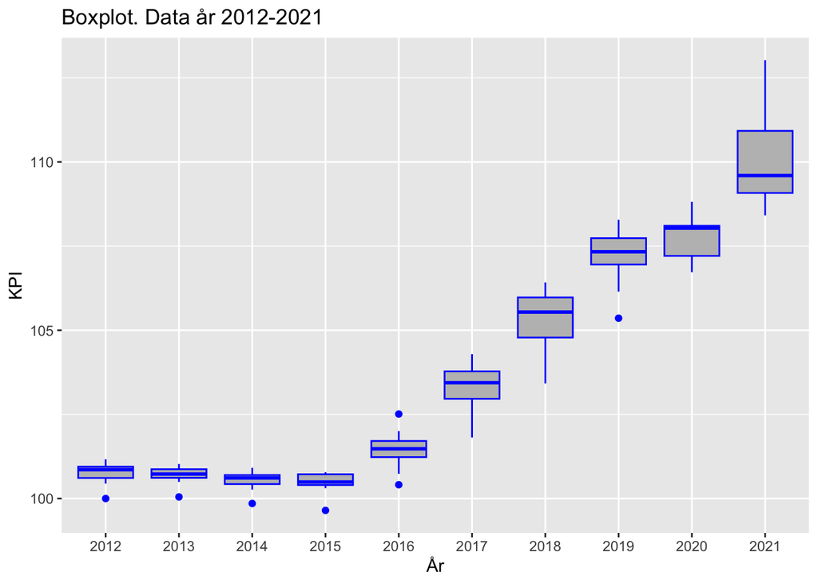

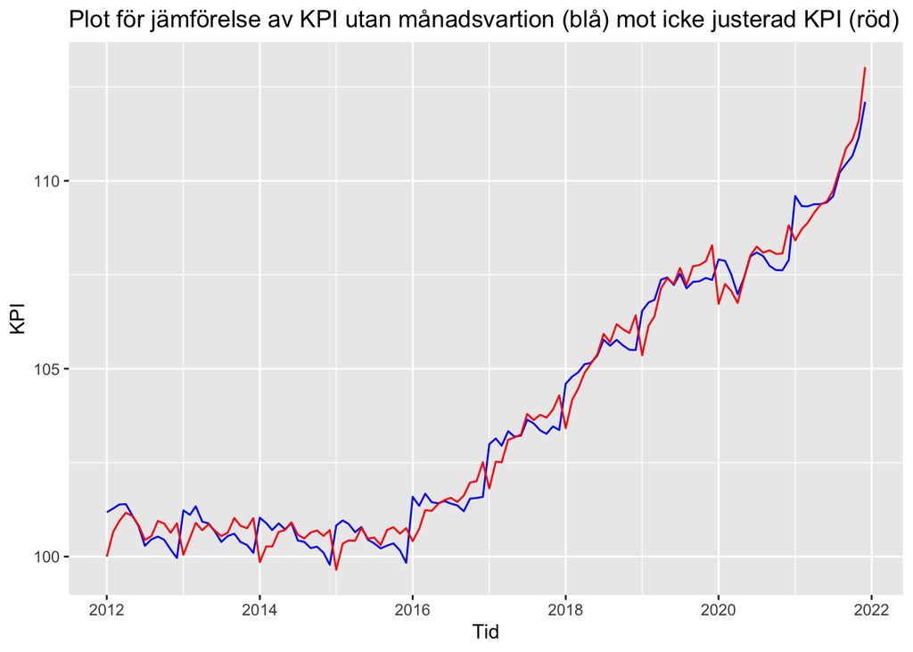

Linjeplot för jämförelse av KPI där månadsvariation tagits bort, Z (blå linje) mot KPI som inte har justerats, Y (röd linje). De tycks följa en någorlunda liknande trend. Inga större skillnader här.

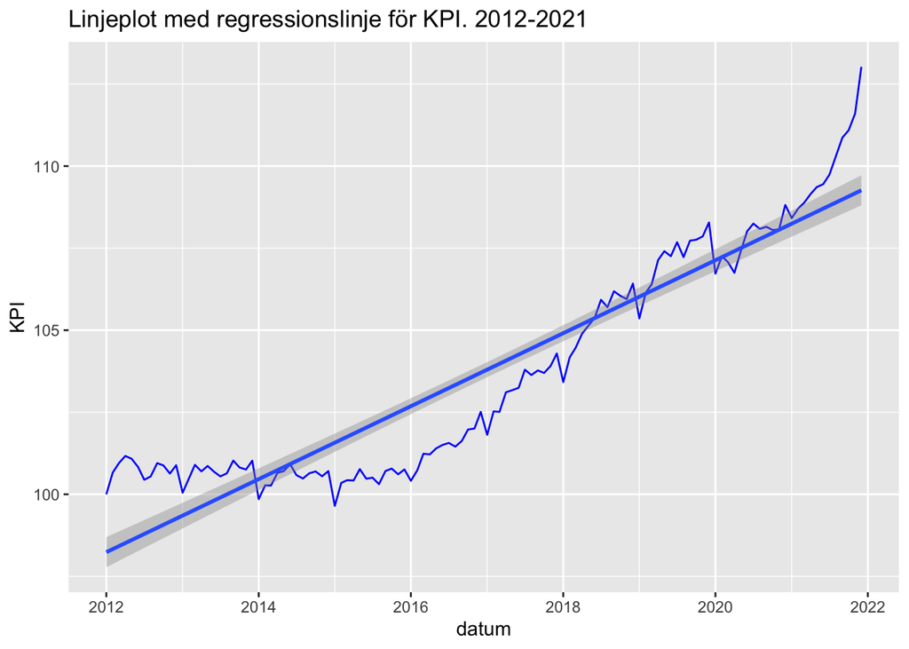

Linjeplot för KPI under hela intervallet 2012-2021. Denna plot med en regressionslinje som tydligt har positiv lutning. KPI ökar alltså över tid.

# Slutsats av tidsseriedata

KPI ökar över tiden. Detta förklarar sig självt av en generellt konstant positiv inflation. Det kan eventuellt föreligga någon typ av säsongsvariation. Detta då det högsta medelvärdet för KPI förekommer i december månad. Och lägsta förekommer i januari. Detta skulle givetvis också enkelt nog kunna förklaras av det faktum att januari är den första månaden varje år och december sista. Med en positiv inflation så kommer det ganska självklart innebära högre KPI i genomsnitt mot slutet av året.